# temp-160806440766550256

### FALL 2020 -> CSE 5334 -> DATA MINING

## Project Title :- Classifier to Predict Ratings for the Reviews

#### UTID :-1001662386

**Website Demo**

- https://youtu.be/Aa2DlJsPXmg

**Website Link**

- https://ratingspredictor.herokuapp.com/

**Github url**

- https://github.com/tiru1056/DMproject

**Kaggale Submission**

- https://www.kaggle.com/tirumalamanukonda/ratings-classifier?scriptVersionId=49346267

**Summary :-** The goal of the project is building a classifier that predicts ratings for the reviews using the boardgame review dataset

The implementation of the project is as follows

- Dataset analysis
- Text Preprocessing
- Vocab and frequency list
- Models prediction
- Data resampling
- Model prediction on resampled data
- Select the best performing of models
- Hyper parameter Tuning
- Findning the Final accuracy
- Building the live appliction

**1.Dataset analysis:-**

- Dataset has user, Id,name coulmns which are not helpful in predicting the ratings, so need to drop those columns
- Visulalize ratings column and we can understand that the dataset has most of the reviews of ratings in the range 6 to 10.
- Since the ratings column is of float type, convert it to integer using the np.round on ratings coulmns.
- Looking at the comments column, it has Nan values where there ratings even though they haven't commented, since we are predicting ratings based on comments that user makes, we can drop all the rows that has Nan values.
- Now we can work on text preprocessing.

**2.Text Preprocessing :-**

- Remove stopwords
- Remove digits
- Remove punctuation
- Convert text to lower
- Stemming
- Remove few text that repeats in all reviews and does not add much information to prediction

**3.Vocab list:-**

- All the reviews are tokenized and converted into words
- Create a bga of words and add all the words
- Sum of all the words that keeps repeating
- word frequency is list is created with the frequencies of each word in reverse order
- below shows the same way of word vectorization using count vectorizer

**4. Count Vectorization:-**

- We will be creating vectors that have a dimensionality equal to the size of our vocabulary, and if the text data features that vocab word, we will put a one in that dimension. Every time we encounter that word again, we will increase the count, leaving 0s everywhere we did not find the word even once, resulting the word vector representation of all the data.

**4. Prediction Models:-**

I have selected MultinomialNB, RandomForestclassifier, XGBoost classifier because they are normally perform better and XGBoost is the most model with success in the kaggale competitions

- **MultinomialNB** The multinomial Naive Bayes classifier is suitable for classification with discrete features (e.g., word counts for text classification). The multinomial distribution normally requires integer feature counts. However, in practice, fractional counts such as tf-idf may also work.
  - alphafloat, default=1.0 -Additive (Laplace/Lidstone) smoothing parameter (0 for no smoothing).
- **RandomForest classifier** A random forest is a meta estimator that fits a number of decision tree classifiers on various sub-samples of the dataset and uses averaging to improve the predictive accuracy and control over-fitting.
  - n_estimators, default=100
  - criterion = “gini”, “entropy” ,default=”gini”
- **XGBoost classifier** XGBoost classifier builds an additive model in a forward stage-wise fashion, it allows for the optimization of arbitrary differentiable loss functions. In each stage n*classes* regression trees are fit on the negative gradient of the binomial or multinomial deviance loss function.
  - learning_ratefloat, default=0.1 :-learning rate shrinks the contribution of each tree by learning_rate. There is a trade-off between learning_rate and n_estimators.
  - n_estimatorsint, default=100 :- The number of boosting stages to perform. Gradient boosting is fairly robust to over-fitting so a large number usually results in better performance.

**Data Resampling:-**

- Data resampling is when their is high imbalance in the dataset
- Data manipulation sampling approaches focus on rescaling the training datasets for balancing all class instances

**Overfitting and Hyperparameters :-**

**Overfitting**

- Overfitting occurs because of using a complex model that closely matches the training set but is unable to generalize to new data

**Hyperparameters tuning**

- The parameters that control the learning process are called hyperparameters and find the optimal values of those params define the hyperparametrs tuning

**Results :-**

- There types are is used
  - original data of full
  - random part of original data
  - resampled data

**Challenges**

```python
import numpy as np
import pandas as pd
import seaborn as sns
import matplotlib.pyplot as plt
from sklearn.linear_model import LinearRegression
from sklearn.model_selection import train_test_split
from sklearn.ensemble import RandomForestRegressor
from wordcloud import WordCloud
from collections import Counter
from sklearn.feature_extraction.text import TfidfVectorizer, CountVectorizer, TfidfTransformer
from sklearn.metrics import accuracy_score
import string
import nltk
import random
from nltk.corpus import stopwords
from string import digits
import sklearn.metrics as metrics
#read the dataset
import re
import io

#ClassificationModels
from sklearn.naive_bayes import MultinomialNB
from xgboost import XGBClassifier
from sklearn.ensemble import RandomForestClassifier
```

```python
#Reading the csv file
df = pd.read_csv('C:/Users/Dell/OneDrive/Documents/bgg-15m-reviews.csv/bgg-15m-reviews.csv')
```

```python
# copy of dataframe
df_copy = df
df_copy = df_copy.loc[:, ~df_copy.columns.str.contains('^Unnamed')]

df_copy.head()
```

|  | user | rating | comment | ID | name |
| --- | --- | --- | --- | --- | --- |
| 0 | Torsten | 10.0 | NaN | 30549 | Pandemic |
| 1 | mitnachtKAUBO-I | 10.0 | Hands down my favorite new game of BGG CON 200... | 30549 | Pandemic |
| 2 | avlawn | 10.0 | I tend to either love or easily tire of co-op ... | 30549 | Pandemic |
| 3 | Mike Mayer | 10.0 | NaN | 30549 | Pandemic |
| 4 | Mease19 | 10.0 | This is an amazing co-op game. I play mostly ... | 30549 | Pandemic |

**Dataset analysis:-**

Below points are understood looking at the dataset

- Dataset has user, Id,name coulmns which are not helpful in predicting the ratings, so need to drop those columns
- Visulalize ratings column and we can understand that the dataset has most of the reviews of ratings in the range 6 to 10.
- Since the ratings column is of float type, convert it to integer using the np.round on ratings coulmns.
- Looking at the comments column, it has Nan values where there ratings even though they haven't commented, since we are predicting ratings based on comments that user makes, we can drop all the rows that has Nan values.
- Now we can work on text preprocessing.

**Data Analysis**

```python
# checking the dataset info
df_copy.info()
```

```
<class 'pandas.core.frame.DataFrame'>
RangeIndex: 15823269 entries, 0 to 15823268
Data columns (total 5 columns):
 #   Column   Dtype
---  ------   -----
 0   user     object
 1   rating   float64
 2   comment  object
 3   ID       int64
 4   name     object
dtypes: float64(1), int64(1), object(3)
memory usage: 603.6+ MB
```

```python
#check the unique values of each column
df_copy.nunique()
```

```
user        351048
rating       10172
comment    2733415
ID           19330
name         18984
dtype: int64
```

- we need to predict the ratings usings the text review data,
- Data columns like name , ID, User details shouldnt effect the ratings as it mostly based on the comments from the list
- so we can drop those columns.

```python
# drop the ['user','ID','name'] columns
df_copy = df_copy.drop(['user','ID','name'],axis = 1)

df_copy.head()
```

|  | rating | comment |
| --- | --- | --- |
| 0 | 10.0 | NaN |
| 1 | 10.0 | Hands down my favorite new game of BGG CON 200... |
| 2 | 10.0 | I tend to either love or easily tire of co-op ... |
| 3 | 10.0 | NaN |
| 4 | 10.0 | This is an amazing co-op game. I play mostly ... |

- the data shows that there are few columns where comments are Nan and are rated 10, so we can drop that rows as we can't predict ratings with out the comments.

```python
# drop the Nan values
df_copy = df_copy.dropna(axis = 0)
df_copy.head()
```

|  | rating | comment |
| --- | --- | --- |
| 1 | 10.0 | Hands down my favorite new game of BGG CON 200... |
| 2 | 10.0 | I tend to either love or easily tire of co-op ... |
| 4 | 10.0 | This is an amazing co-op game. I play mostly ... |
| 5 | 10.0 | Hey! I can finally rate this game I've been pl... |
| 8 | 10.0 | Love it- great fun with my son. 2 plays so far... |

```
<function matplotlib.pyplot.show(close=None, block=None)>
```

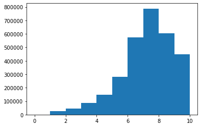

```python
plt.hist(df_copy["rating"])
plt.show
```

```python
#ratings are float values and randomly distributed, rounding them to integers
df_copy["rating"] = np.round(df_copy["rating"])
```

**Text Prepocessing**

```python
def preprocess_text(df, remove_special=True):
    #Remove links
    df["comment"] = df["comment"].apply(lambda x: re.sub(r'https?:\/\/.*?[\s+]', '', x.replace("|"," ") + " "))

    #Strip Punctation
    df["comment"]  = df["comment"].apply(lambda x: re.sub(r'[^\w\s]','',x))

    #Remove Non-words
    df["comment"]  = df["comment"].apply(lambda x: re.sub(r'[^a-zA-Z\s]','',x))

    #To lower
    df["comment"]  = df["comment"].apply(lambda x: x.lower())

    #Remove multiple letter repating words
    df["comment"]  = df["comment"].apply(lambda x: re.sub(r'([a-z])\1{2,}[\s|\w]*','',x))


    #Remove short/long words
    df["comment"]  = df["comment"].apply(lambda x: re.sub(r'(\b\w{0,3})?\b','',x))
    df["comment"]  = df["comment"].apply(lambda x: re.sub(r'(\b\w{30,1000})?\b','',x))



    return df
```

```python
#Preprocessing the comments
Cleaned_dfcopy = preprocess_text(df_copy)
Cleaned_dfcopy
```

|  | rating | comment |
| --- | --- | --- |
| 1 | 10.0 | hands down favorite game played time... |
| 2 | 10.0 | tend either love easily tire coop games p... |
| 4 | 10.0 | this amazing coop game play mostly with w... |
| 5 | 10.0 | finally rate this game been playtesting ... |
| 8 | 10.0 | love great with plays looking forward ... |
| ... | ... | ... |
| 15823242 | 10.0 | collectors bundle with friend mine |
| 15823247 | 10.0 | belekokio gerumo |
| 15823253 | 10.0 | excelente mejor prob |
| 15823264 | 8.0 | turn based preview looks very promising game ... |
| 15823265 | 8.0 |  |

2995023 rows × 2 columns

```python
#Removing stopwords and few repeating words in all reviews that doesnt convey much information
stpwrds = stopwords.words('english')
stpwrds.extend(('game','people','really','board','games','play','player','one','plays','cards','would','played','players'))
Cleaned_dfcopy['comment'] = Cleaned_dfcopy['comment'].apply(lambda x: ' '.join([word for word in x.split() if word not in (stpwrds)]))
Cleaned_dfcopy.head()
```

|  | rating | comment |
| --- | --- | --- |
| 1 | 10.0 | hands favorite times good pandemic wont stores... |
| 2 | 10.0 | tend either love easily tire coop pandemic joi... |
| 4 | 10.0 | amazing coop mostly wife cant imagine getting ... |
| 5 | 10.0 | finally rate playtesting couple years like pan... |
| 8 | 10.0 | love great looking forward |

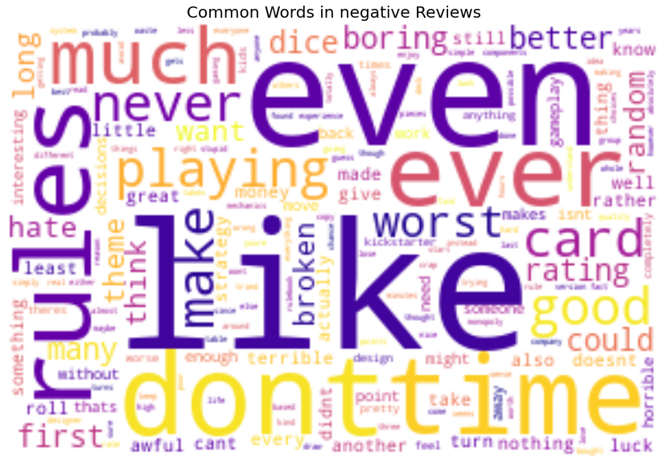

```python
#displaying the wordcloud of most ratings lessthan 2

negative = Cleaned_dfcopy.loc[Cleaned_dfcopy['rating'] < 2]
words = Counter([comm for comm in " ".join(negative['comment']).split()])
wc = WordCloud(width=300, height=200,colormap='plasma',background_color='white').generate_from_frequencies(dict(words.most_common(200)))
plt.figure(figsize=(15,10))
plt.imshow(wc, interpolation='bilinear')
plt.title('Common Words in negative Reviews', fontsize=20)
plt.axis('off');
plt.show()
```

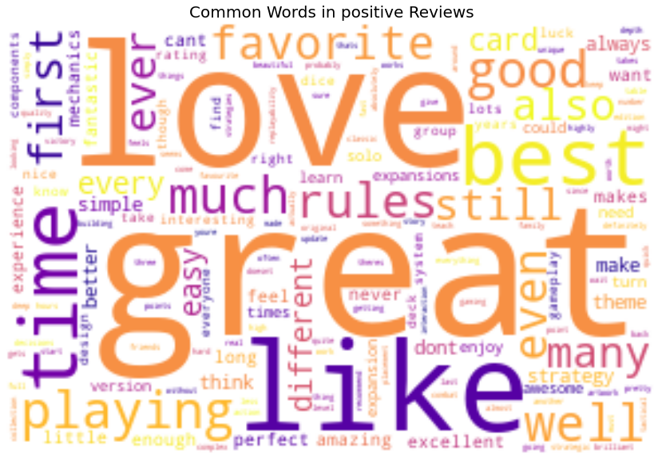

```python
#displaying the wordcloud of most ratings greater than 9


positive = Cleaned_dfcopy.loc[Cleaned_dfcopy['rating'] > 9]
words = Counter([comm for comm in " ".join(positive['comment']).split()])
wc = WordCloud(width=300, height=200,colormap='plasma',background_color='white').generate_from_frequencies(dict(words.most_common(200)))
plt.figure(figsize=(15,10))
plt.imshow(wc, interpolation='bilinear')
plt.title('Common Words in positive Reviews', fontsize=20)
plt.axis('off');

plt.show()
```

```python
#word embeddings
#Words with the frequencies in reverse sort
vec1 = CountVectorizer(stop_words = 'english').fit(Cleaned_dfcopy['comment'])
bag_of_words_copy = vec1.transform(Cleaned_dfcopy['comment'])
sum_words_copy = bag_of_words_copy.sum(axis=0)
words_freq_copy = [(word, sum_words_copy[0, idx]) for word, idx in vec1.vocabulary_.items()]
words_freq_copy =sorted(words_freq_copy, key = lambda x: x[1], reverse=True)
words_freq_copy
```

```
[('like', 575869),
 ('good', 440801),
 ('great', 368997),
 ('time', 295845),
 ('rules', 227646),
 ('playing', 227028),
 ('card', 218944),
 ('little', 216403),
 ('dont', 215177),
 ('better', 204206),
 ('theme', 194517),
 ('interesting', 190084),
 ('love', 185284),
 ('nice', 182958),
 ('think', 179320),
 ('best', 163758),
 ('simple', 161172),
 ('easy', 158231),
 ('make', 158171),
 ('dice', 144198),
 ('different', 140873),
 ('long', 138493),
 ('strategy', 135429),
 ('luck', 127773),
 ('quite', 124660),
 ('feel', 123457),
 ('pretty', 121060),
 ('need', 116515),
 ('rating', 116090),
 ('turn', 115525),
 ('want', 111929),
 ('enjoy', 106849),
 ('mechanics', 104628),
 ('quick', 104189),
 ('version', 100734),
 ('makes', 96357),
 ('points', 95393),
 ('doesnt', 91826),
 ('light', 91766),
 ('times', 91058),
```

[output cut: 946 more lines]

```
 ('cardboard', 7128),
 ('graphic', 7128),
 ('weak', 7120),
 ('category', 7119),
 ('heard', 7117),
 ('gone', 7115),
 ('figures', 7103),
 ('narrative', 7088),
 ('says', 7085),
 ('normal', 7085),
 ('suffers', 7079),
 ('christmas', 7077),
 ('benefit', 7073),
 ('jugadores', 7063),
 ...]
```

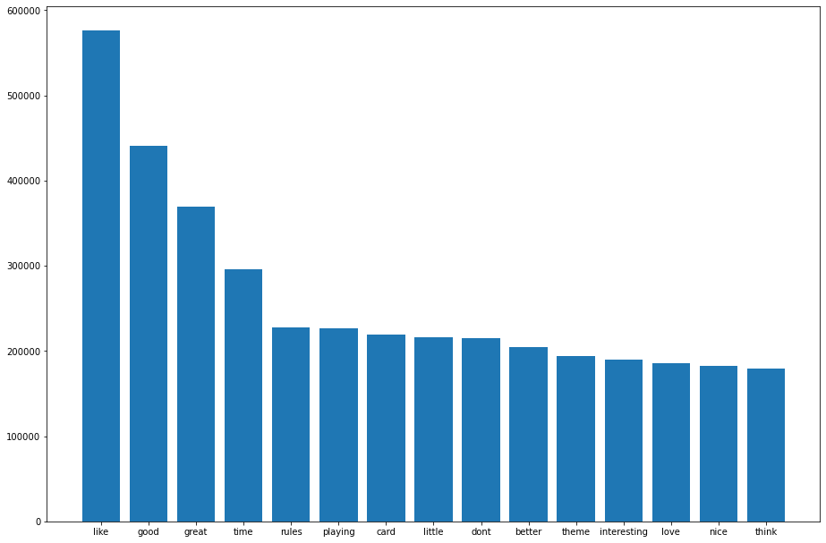

```python
# Top 15 words in reviews
def get_top_n_words(corpus, n=None):
    vec = CountVectorizer(stop_words = 'english').fit(corpus)
    bag_of_words = vec.transform(corpus)
    sum_words = bag_of_words.sum(axis=0)
    words_freq = [(word, sum_words[0, idx]) for word, idx in vec.vocabulary_.items()]
    words_freq =sorted(words_freq, key = lambda x: x[1], reverse=True)
    return words_freq[:n]
common_words = get_top_n_words(Cleaned_dfcopy['comment'], 15)
lan=[]
std=[]
for word, freq in common_words:
    lan.append(word)
    std.append(freq)
fig = plt.figure()
ax = fig.add_axes([0,0,2,2])
ax.bar(lan,std)
plt.show()
```

```python
cv = CountVectorizer(max_features =2000)
features = cv.fit_transform(Cleaned_dfcopy['comment'])

x_train, x_test, y_train, y_test = train_test_split(features, Cleaned_dfcopy['rating'], test_size = 0.3 ,random_state = 99)
```

```python
##Multinomialnaviesbayes model
MB = MultinomialNB()
MB.fit(x_train, y_train)

print("Train accuracy: ", MB.score(x_train,y_train))
print("Test accuracy: ", MB.score(x_test,y_test))
```

```
Train accuracy:  0.30923589421688175
Test accuracy:  0.3052285624931136
```

```python
##Multinomialnaviesbayes model
RF = RandomForestClassifier(n_jobs =-1)
RF.fit(x_train, y_train)

print("Train accuracy: ", RF.score(x_train,y_train))
print("Test accuracy: ", RF.score(x_test,y_test))
```

[output not shown]

```python
##Multinomialnaviesbayes model
XG = XGBClassifier()
XG.fit(x_train, y_train)

print("Train accuracy: ", XG.score(x_train,y_train))
print("Test accuracy: ", XG.score(x_test,y_test))
```

[output not shown]

**Fractional dataset**-

```python
#Train and test data split, I initially worked with full data
#and its taking longer times, so i replaced with frac 0.2 of the data and tried

import math
New_df = Cleaned_dfcopy.sample(frac = 0.2)
X = New_df['comment']
y= New_df['rating']
x_train, x_test, y_train, y_test = train_test_split(X, y, test_size = 0.3 ,random_state = 99)
```

```python
##let us get the features for our training texts with count vectorizer
cv = CountVectorizer(max_features =2000)

train_features = cv.fit_transform(x_train).toarray()
test_features = cv.fit_transform(x_test).toarray()
```

```python
##Multinomialnaviesbayes model
MB = MultinomialNB()
MB.fit(train_features, y_train)
y_pred =MB.predict(test_features)

print("Accuracy: ", metrics.accuracy_score(y_test, y_pred))
```

```
Accuracy:  0.22997518113320942
```

```python
##RandomForestClassifier
RFC = RandomForestClassifier( n_jobs= -1)
RFC.fit(train_features, y_train)
y_pred = RFC.predict(test_features)

print("Accuracy: ", metrics.accuracy_score(y_test, y_pred))
```

[output not shown]

```python
##XGBClassifier
model = XGBClassifier()
model.fit(x_train, y_train)
y_pred =model.predict(x_test)

import sklearn.metrics as metrics
print("Accuracy: ", metrics.accuracy_score(y_test, y_pred))
```

[output not shown]

**Data Resampling**

- Trying resampling the data and observing the performance using resampled data

**All the above analysis is done again with the below resampled data**

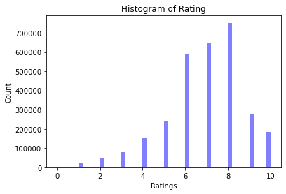

```python
#plot histogram of ratings

num_bins = 50
n, bins, patches = plt.hist(df_copy.rating, num_bins, facecolor='blue', alpha=0.5)

plt.title('Histogram of Rating')
plt.xlabel('Ratings')
plt.ylabel('Count')
plt.show()
```

```python
df_copy['rating_int'] = df_copy.rating.astype(int)

def sample(rating):
    sample = df_copy[df_copy.rating_int == rating].sample(3000)
    return sample
```

```python
df_copy.isnull().sum()
```

```
rating        0
comment       0
rating_int    0
dtype: int64
```

```python
len(df_copy['rating'].unique())
```

```
11
```

```python
reviews_sampled = pd.concat([sample(1),sample(2),sample(3),sample(4),sample(5),sample(6),sample(7),sample(8),sample(9),sample(10)])
```

```python
reviews_sampled
```

|  | rating | comment | rating_int |
| --- | --- | --- | --- |
| 15810085 | 1.0 | real ouija bunch nonsense | 1 |
| 8646942 | 1.0 | lack theme offensive movie franchise much dept... | 1 |
| 5147971 | 1.0 | worst ever | 1 |
| 13068445 | 1.0 | suppose penandpaper activity fits definition n... | 1 |
| 13690514 | 1.0 | education casting | 1 |
| ... | ... | ... | ... |
| 6554575 | 10.0 | update even better thought currently clear int... | 10 |
| 5411611 | 10.0 | slow reveal much person | 10 |
| 15394070 | 10.0 | chance jouer proto solomon kane premiers chapi... | 10 |
| 50492 | 10.0 | family version solo deck solo deck solo family... | 10 |
| 84469 | 10.0 | best | 10 |

30000 rows × 3 columns

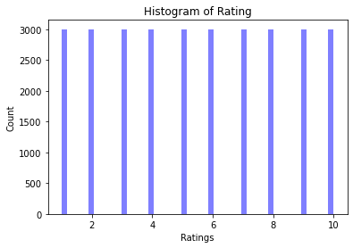

```python
#plot histogram of ratings after resampling

num_bins = 50
n, bins, patches = plt.hist(reviews_sampled.rating, num_bins, facecolor='blue', alpha=0.5)

plt.title('Histogram of Rating')
plt.xlabel('Ratings')
plt.ylabel('Count')
plt.show()
```

```python
def preprocess_text(df, remove_special=True):
    #Remove links
    df["comment"] = df["comment"].apply(lambda x: re.sub(r'https?:\/\/.*?[\s+]', '', x.replace("|"," ") + " "))

    #Strip Punctation
    df["comment"]  = df["comment"].apply(lambda x: re.sub(r'[^\w\s]','',x))

    #Remove Non-words
    df["comment"]  = df["comment"].apply(lambda x: re.sub(r'[^a-zA-Z\s]','',x))

    #To lower
    df["comment"]  = df["comment"].apply(lambda x: x.lower())

    #Remove multiple letter repating words
    df["comment"]  = df["comment"].apply(lambda x: re.sub(r'([a-z])\1{2,}[\s|\w]*','',x))


    #Remove short/long words
    df["comment"]  = df["comment"].apply(lambda x: re.sub(r'(\b\w{0,3})?\b','',x))
    df["comment"]  = df["comment"].apply(lambda x: re.sub(r'(\b\w{30,1000})?\b','',x))



    return df
```

```python
#Preprocessing
Cleaned_df = preprocess_text(reviews_sampled)
Cleaned_df
```

|  | rating | comment | rating_int |
| --- | --- | --- | --- |
| 15810085 | 1.0 | real ouija bunch nonsense | 1 |
| 8646942 | 1.0 | lack theme offensive movie franchise much dept... | 1 |
| 5147971 | 1.0 | worst ever | 1 |
| 13068445 | 1.0 | suppose penandpaper activity fits definition n... | 1 |
| 13690514 | 1.0 | education casting | 1 |
| ... | ... | ... | ... |
| 6554575 | 10.0 | update even better thought currently clear int... | 10 |
| 5411611 | 10.0 | slow reveal much person | 10 |
| 15394070 | 10.0 | chance jouer proto solomon kane premiers chapi... | 10 |
| 50492 | 10.0 | family version solo deck solo deck solo family... | 10 |
| 84469 | 10.0 | best | 10 |

30000 rows × 3 columns

```python
#preprocess resampled data
stpwrds = stopwords.words('english')
stpwrds.extend(('game','people','really','board','games','play','player','one','plays','cards','would','played','players'))
Cleaned_df['comment'] = Cleaned_df['comment'].apply(lambda x: ' '.join([word for word in x.split() if word not in (stpwrds)]))
Cleaned_df.head()
```

|  | rating | comment | rating_int |
| --- | --- | --- | --- |
| 15810085 | 1.0 | real ouija bunch nonsense | 1 |
| 8646942 | 1.0 | lack theme offensive movie franchise much dept... | 1 |
| 5147971 | 1.0 | worst ever | 1 |
| 13068445 | 1.0 | suppose penandpaper activity fits definition n... | 1 |
| 13690514 | 1.0 | education casting | 1 |

```python
from sklearn import feature_extraction
from sklearn.feature_extraction.text import TfidfVectorizer, CountVectorizer
count_vectorizer = feature_extraction.text.TfidfVectorizer(stop_words='english')
```

```python
#word embeddings for resampled data
vec = CountVectorizer(stop_words = 'english').fit(Cleaned_df['comment'])
bag_of_words = vec.transform(Cleaned_df['comment'])
sum_words = bag_of_words.sum(axis=0)
words_freq = [(word, sum_words[0, idx]) for word, idx in vec.vocabulary_.items()]
words_freq =sorted(words_freq, key = lambda x: x[1], reverse=True)
words_freq
```

```
[('like', 5727),
 ('good', 3809),
 ('time', 3210),
 ('great', 3003),
 ('dont', 2607),
 ('playing', 2512),
 ('rules', 2469),
 ('card', 2289),
 ('better', 2091),
 ('make', 1873),
 ('little', 1835),
 ('interesting', 1813),
 ('theme', 1811),
 ('think', 1696),
 ('love', 1694),
 ('long', 1605),
 ('dice', 1555),
 ('best', 1466),
 ('nice', 1393),
 ('luck', 1365),
 ('strategy', 1354),
 ('simple', 1330),
 ('want', 1285),
 ('easy', 1276),
 ('different', 1264),
 ('turn', 1231),
 ('rating', 1205),
 ('feel', 1169),
 ('need', 1126),
 ('pretty', 1115),
 ('doesnt', 1044),
 ('didnt', 1005),
 ('quite', 1004),
 ('mechanics', 1002),
 ('random', 970),
 ('times', 963),
 ('enjoy', 939),
 ('points', 919),
 ('makes', 912),
 ('version', 902),
```

[output cut: 946 more lines]

```
 ('military', 77),
 ('figures', 77),
 ('significant', 77),
 ('travel', 77),
 ('scale', 76),
 ('absolute', 76),
 ('computer', 76),
 ('tend', 76),
 ('saying', 76),
 ('laugh', 76),
 ('path', 76),
 ('cardboard', 76),
 ('struggle', 76),
 ('older', 76),
 ...]
```

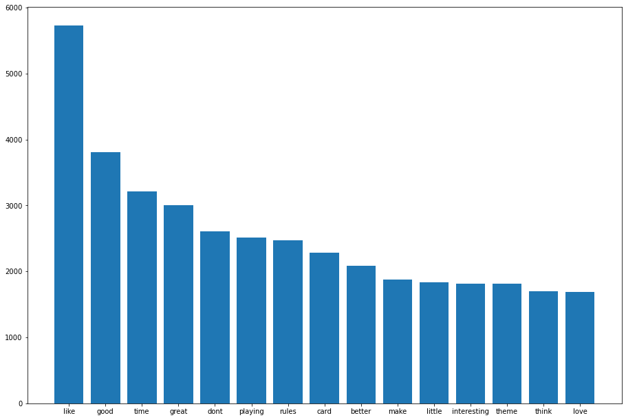

```python
#top 15 words of resampled data
def get_top_n_words(corpus, n=None):
    vec = CountVectorizer(stop_words = 'english').fit(corpus)
    bag_of_words = vec.transform(corpus)
    sum_words = bag_of_words.sum(axis=0)
    words_freq = [(word, sum_words[0, idx]) for word, idx in vec.vocabulary_.items()]
    words_freq =sorted(words_freq, key = lambda x: x[1], reverse=True)
    return words_freq[:n]
common_words = get_top_n_words(Cleaned_df['comment'], 15)
lan=[]
std=[]
for word, freq in common_words:
    lan.append(word)
    std.append(freq)
fig = plt.figure()
ax = fig.add_axes([0,0,2,2])
ax.bar(lan,std)
plt.show()
```

```python
# train and test data split and vectorization
x = np.array(Cleaned_df.comment)
y = np.array(Cleaned_df.rating)

x_train, x_test, y_train, y_test = train_test_split(x, y, test_size=0.3)


count_vect = CountVectorizer(min_df=0.001, max_df=0.5, max_features=1000)
X_train_counts = count_vect.fit_transform(x_train)
X_test_counts = count_vect.fit_transform(x_test)


count_vect = TfidfTransformer()
tf_transformer = TfidfTransformer().fit(X_train_counts)
x_train = tf_transformer.transform(X_train_counts)
x_train = x_train.toarray()
print(x_train.shape)

tf_transformer = TfidfTransformer().fit(X_test_counts)
x_test = tf_transformer.transform(X_test_counts)
```

```
(21000, 1000)
```

```python
#MultinomialNB
model = MultinomialNB()
model.fit(x_train, y_train)
y_pred =model.predict(x_test)

print("Train accuracy: ", model.score(x_train,y_train))
print("Test accuracy: ", model.score(x_test,y_test))
```

```
Train accuracy:  0.32880952380952383
Test accuracy:  0.10066666666666667
```

```python
#RandomForest
model = RandomForestClassifier(n_estimators=100, random_state=0)
model.fit(x_train, y_train)
y_pred =model.predict(x_test)

print("Train accuracy: ", model.score(x_train,y_train))
print("Test accuracy: ", model.score(x_test,y_test))
```

```
Train accuracy:  0.8512380952380952
Test accuracy:  0.10922222222222222
```

**Overfitting**- RandomForestClassifier is clearly overfitting in this case, as the training accuracy is 85.12% and test accuracy is 10.922

```python
#XGBclassifier
model = XGBClassifier()
model.fit(x_train, y_train)
y_pred =model.predict(x_test)

print("Train accuracy: ", model.score(x_train,y_train))
print("Test accuracy: ", model.score(x_test,y_test))
```

```
[01:18:50] WARNING: C:/Users/Administrator/workspace/xgboost-win64_release_1.3.0/src/learner.cc:1061: Starting in XGBoost 1.3.0, the default evaluation metric used with the objective 'multi:softprob' was changed from 'merror' to 'mlogloss'. Explicitly set eval_metric if you'd like to restore the old…
Train accuracy:  0.569952380952381
Test accuracy:  0.10988888888888888
```

**Analysis**

- Of all the classifiers, here XGBoost classifier has better accuracy, lets try hyperparamter tunning

```python
#XGBclassifier
model = XGBClassifier(max_depth=3, min_child_weight= 0.5)
model.fit(x_train, y_train)
y_pred =model.predict(x_test)

print("Train accuracy: ", model.score(x_train,y_train))
print("Test accuracy: ", model.score(x_test,y_test))
```

```
[01:33:33] WARNING: C:/Users/Administrator/workspace/xgboost-win64_release_1.3.0/src/learner.cc:1061: Starting in XGBoost 1.3.0, the default evaluation metric used with the objective 'multi:softprob' was changed from 'merror' to 'mlogloss'. Explicitly set eval_metric if you'd like to restore the old…
Train accuracy:  0.4197142857142857
Test accuracy:  0.11088888888888888
```

**Hyperparameter tuning** :-

- Adjusting the values of max_depth, min_child_weight we have got a better accuracy here
- Both the max_depth, min_child_weight parameters tends to overfitting we decrease more and if you increase high they will underfit

**Referrences**

- https://www.kaggle.com/jvanelteren/boardgamegeek-reviews
- https://scikit-learn.org/stable/
- prof. sridhar nerur class slides
- https://www.kaggle.com/pereirasteeven/board-game-rating-predictor
- https://github.com/jushih/Sentiment-Analysis